# Lecture 4: Statistical Measures, Probability Distributions and Modeling Workshop

Sharon Tan

9 Feb 2021

# Building Dashboards for Bank Credit Risk Analyses

**Last week, we started building the Bank Credit Risk Analyses Dashboards. We created frequency distributions and plotted either the barchart or pie chart for categorical variables and histograms for numerical variables. We plotted the scatterplot to compare relationship of two variables and conducted the Pareto Analyses on Customer Savings** **This week we will continue to build on the Dashboards by adding statistical measures, goodness of fit and outlier analyses.**

## 1) Preparation

*- Start by installing the packges you need. I will set message=FALSE and warning=FALSE so they will not show up in the HTML output.*

### Install Packages

```r
#install.packages("psych") #only need to run this code once to install the package
library("dplyr") #need to call the libary before you use the package
library("tidyr")
library("rpivotTable")
library("knitr")
library("psych")
```

### Set Working Directory and Importing Data

The worksheet Base Data in the Excel file Bank Credit Risk Data provides information about 425 bank customers who had applied for loans. Each of the column is defined as follows:

- `Loan Purpose` : Type of purpose for the loan applied
- `Checking` : Checking account balance
- `Savings` : Savings account balance
- `Months Customer`: Number of months has been a customer of the bank
- `Months Employed`: Number of months in employment
- `Gender`: Gender
- `Marital Status`: Marital status
- `Age`: Age in years
- `Housing`: Housing type
- `Years`: Number of years at current residence
- `Job`: Job type
- `Credit Risk`: Credit-risk classification by the bank

*- Be sure to set working directory and import the datafile.*

```r
#put in your working directory folder pathname
setwd("~/Dropbox/Teaching/BT1101/BT1101AY2021S1/Inclass Lecture/Lecture 4")
#import excel file into RStudio
library(readxl)
Bank_Credit_Risk_Data <- read_excel("Bank Credit Risk Data.xlsx",
                               sheet = "Base Data", skip = 2)
View(Bank_Credit_Risk_Data)
BD<-Bank_Credit_Risk_Data
```

### Checking Data

*- Check that you have entered the data correctly by using the head() and summary() functions.*

```r
head(BD)
```

```
## # A tibble: 6 x 12
##   `Loan Purpose` Checking Savings `Months Custome… `Months Employe… Gender
##   <chr>             <dbl>   <dbl>            <dbl>            <dbl> <chr>
## 1 Small Applian…        0     739               13               12 M
## 2 Furniture             0    1230               25                0 M
## 3 New Car               0     389               19              119 M
## 4 Furniture           638     347               13               14 M
## 5 Education           963    4754               40               45 M
## 6 Furniture          2827       0               11               13 M
## # … with 6 more variables: `Marital Status` <chr>, Age <dbl>, Housing <chr>,
## #   Years <dbl>, Job <chr>, `Credit Risk` <chr>
```

```r
summary(BD)
```

```
##  Loan Purpose          Checking        Savings      Months Customer
##  Length:425         Min.   :    0   Min.   :    0   Min.   : 5.0
##  Class :character   1st Qu.:    0   1st Qu.:  228   1st Qu.:13.0
##  Mode  :character   Median :    0   Median :  596   Median :19.0
##                     Mean   : 1048   Mean   : 1813   Mean   :22.9
##                     3rd Qu.:  560   3rd Qu.:  921   3rd Qu.:28.0
##                     Max.   :19812   Max.   :19811   Max.   :73.0
##  Months Employed    Gender          Marital Status          Age
##  Min.   :  0.0   Length:425         Length:425         Min.   :18.0
##  1st Qu.:  6.0   Class :character   Class :character   1st Qu.:26.0
##  Median : 20.0   Mode  :character   Mode  :character   Median :32.0
##  Mean   : 31.9                                         Mean   :34.4
##  3rd Qu.: 47.0                                         3rd Qu.:41.0
##  Max.   :119.0                                         Max.   :73.0
##    Housing              Years          Job            Credit Risk
##  Length:425         Min.   :1.00   Length:425         Length:425
##  Class :character   1st Qu.:2.00   Class :character   Class :character
##  Mode  :character   Median :3.00   Mode  :character   Mode  :character
##                     Mean   :2.84
##                     3rd Qu.:4.00
##                     Max.   :4.00
```

```r
str(BD) #You can view this in the Global Environment window
```

```
## tibble [425 × 12] (S3: tbl_df/tbl/data.frame)
##  $ Loan Purpose   : chr [1:425] "Small Appliance" "Furniture" "New Car" "Furniture" ...
##  $ Checking       : num [1:425] 0 0 0 638 963 ...
##  $ Savings        : num [1:425] 739 1230 389 347 4754 ...
##  $ Months Customer: num [1:425] 13 25 19 13 40 11 13 14 37 25 ...
##  $ Months Employed: num [1:425] 12 0 119 14 45 13 16 2 9 4 ...
##  $ Gender         : chr [1:425] "M" "M" "M" "M" ...
##  $ Marital Status : chr [1:425] "Single" "Divorced" "Single" "Single" ...
##  $ Age            : num [1:425] 23 32 38 36 31 25 26 27 25 43 ...
##  $ Housing        : chr [1:425] "Own" "Own" "Own" "Own" ...
##  $ Years          : num [1:425] 3 1 4 2 3 1 3 1 2 1 ...
##  $ Job            : chr [1:425] "Unskilled" "Skilled" "Management" "Unskilled" ...
##  $ Credit Risk    : chr [1:425] "Low" "High" "High" "High" ...
```

## 2) Building the Credit Risk Dashboards

### A) Customer Profile Dashboard

**Purpose: To understand the customer profile better. (Assume: customer characteristics of interests are gender, marital status, age, savings)**

#### i) Descriptive Statistics for customer demographics

##### - Categorical Variables: Gender, Marital Status

```r
#Pie chart for Gender
GenderFreq<-BD%>%count(Gender)
kable(GenderFreq, caption = "Frequency of Bank Customers by Gender")
```

Frequency of Bank Customers by Gender

| Gender | n |
| --- | --- |
| F | 135 |
| M | 290 |

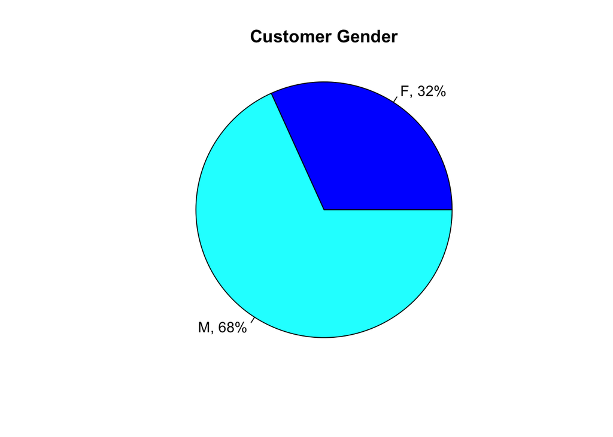

```r
slice.gen <- GenderFreq$n
gen.piepercent <- 100*round(GenderFreq$n/sum(GenderFreq$n),2)
label<-GenderFreq$Gender
label<-paste(label,",",sep="")
label<-paste(label,gen.piepercent) #default of sep=" "
label<-paste(label,"%",sep="")
pie(slice.gen,labels=label, col=c("blue","cyan"),radius=1, main="Customer Gender")
```

```r
#Pie Chart for Marital Status
MSFreq<-BD%>%count(`Marital Status`)
kable(MSFreq, caption = "Frequency of Bank Customers by Marital Status")
```

Frequency of Bank Customers by Marital Status

| Marital Status | n |
| --- | --- |
| Divorced | 156 |
| Married | 36 |
| Single | 233 |

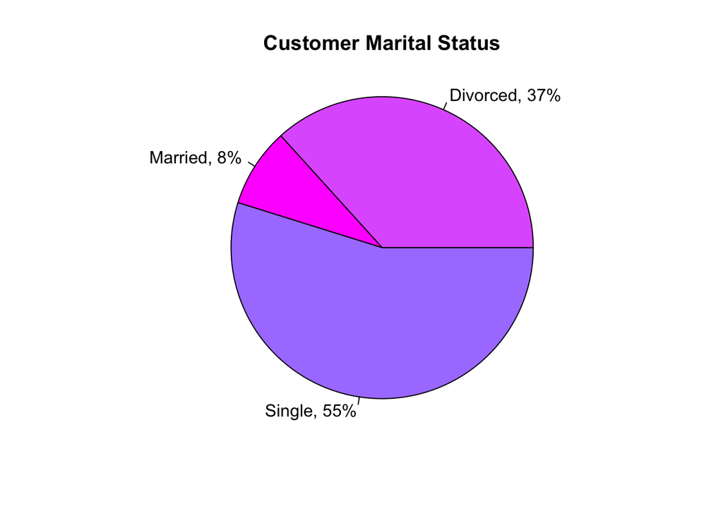

```r
slice.MS <- MSFreq$n
MS.piepercent <- 100*round(MSFreq$n/sum(MSFreq$n),2)
label<-MSFreq$`Marital Status`
label<-paste(label,",",sep="")
label<-paste(label,MS.piepercent) #default of sep=" "
label<-paste(label,"%",sep="")
pie(slice.MS,labels=label, col=c("mediumorchid1","magenta","mediumpurple1"),radius=1, main="Customer Marital Status")
```

##### - Continuous variables - Age & Savings

###### * Statistical Summary for Customer Age and Savings

```r
# Manually generate each summary statistic (mean, sd, min, max, median) then combine into a table
Age<-c(mean(BD$Age),sd(BD$Age),min(BD$Age),max(BD$Age),median(BD$Age))
Savings<-c(mean(BD$Savings),sd(BD$Savings),min(BD$Savings),max(BD$Savings),median(BD$Savings))
tab1<-rbind(Age,Savings)
kable(tab1, row.names = TRUE, col.names = c("Mean","Std Dev", "Min","Max","Median"), caption = "Descriptive Statistics for Age and Savings - manual")
```

Descriptive Statistics for Age and Savings - manual

|  | Mean | Std Dev | Min | Max | Median |
| --- | --- | --- | --- | --- | --- |
| Age | 34.39765 | 11.04513 | 18 | 73 | 32 |
| Savings | 1812.56235 | 3597.28502 | 0 | 19811 | 596 |

```r
# Use describe() function in psych package to generate the descriptive statistics
dfage <- describe(BD$Age, IQR=TRUE)
dfsavings <- describe(BD$Savings, IQR=TRUE)
df.desc1<-rbind(dfage,dfsavings)
df.desc1$trimmed <- df.desc1$mad <- df.desc1$se <- NULL # remove se, mad and trimmed if not needed
df.desc1$vars[1]<-"Age"
df.desc1$vars[2]<-"Savings"
kable(df.desc1, row.names = FALSE, caption = "Descriptive Statistics for Age and Savings - using psych package")
```

Descriptive Statistics for Age and Savings - using psych package

| vars | n | mean | sd | median | min | max | range | skew | kurtosis | IQR |
| --- | --- | --- | --- | --- | --- | --- | --- | --- | --- | --- |
| Age | 425 | 34.39765 | 11.04513 | 32 | 18 | 73 | 55 | 0.9609948 | 0.4034778 | 15 |
| Savings | 425 | 1812.56235 | 3597.28502 | 596 | 0 | 19811 | 19811 | 3.0112207 | 8.7630268 | 693 |

```r
# for Coefficient of Skewness and Kurtosis used in R is Type 3 default -
# which is similar to the formulas in our text and lecture notes.
# However for Kurtosis, the formula in R is less by 3. The interpretation is also adjusted such that
# for kurtosis >0 means distribution has high peaks and skinny tails.
# while kurtosis  <0 means distribution has low peak and heavy tails.
cs.age<-(sum((BD$Age-mean(BD$Age))**3)/nrow(BD))/(sd(BD$Age))**3
print(c("Coefficient of Skewness (Age): ", cs.age))
```

```
## [1] "Coefficient of Skewness (Age): " "0.96099476005924"
```

```r
ck.age<-(sum((BD$Age-mean(BD$Age))**4)/nrow(BD))/((sd(BD$Age))**4)
print(c("Coefficient of Kurtosis (Age): ", ck.age))
```

```
## [1] "Coefficient of Kurtosis (Age): " "3.40347777399678"
```

```r
cs.save<-(sum((BD$Savings-mean(BD$Savings))**3)/nrow(BD))/(sd(BD$Savings))**3
print(c("Coefficient of Skewness (Savings): ", cs.save))
```

```
## [1] "Coefficient of Skewness (Savings): " "3.01122071874119"
```

```r
ck.save<-(sum((BD$Savings-mean(BD$Savings))**4)/nrow(BD))/((sd(BD$Savings))**4)
print(c("Coefficient of Kurtosis (Savings): ", ck.save))
```

```
## [1] "Coefficient of Kurtosis (Savings): " "11.7630268258091"
```

```r
dfage <- describe(BD$Age, IQR=TRUE)
dfsavings <- describe(BD$Savings, IQR=TRUE)
df.desc1<-rbind(dfage,dfsavings)
df.desc1$trimmed <- df.desc1$mad <- df.desc1$se <- NULL # remove se, mad and trimmed if not needed
df.desc1$vars<-c("Age","Saving")
kable(df.desc1, row.names = FALSE, caption = "Descriptive Statistics for Age and Savings - using psych package")
```

Descriptive Statistics for Age and Savings - using psych package

| vars | n | mean | sd | median | min | max | range | skew | kurtosis | IQR |
| --- | --- | --- | --- | --- | --- | --- | --- | --- | --- | --- |
| Age | 425 | 34.39765 | 11.04513 | 32 | 18 | 73 | 55 | 0.9609948 | 0.4034778 | 15 |
| Saving | 425 | 1812.56235 | 3597.28502 | 596 | 0 | 19811 | 19811 | 3.0112207 | 8.7630268 | 693 |

###### * Histograms & Frequency Distributions for Customer Age and Savings

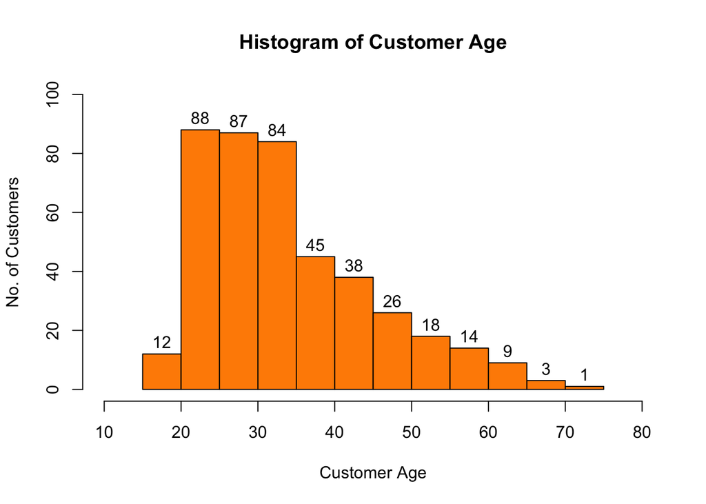

```r
# Age
# create histogram
h1<-hist(BD$Age, main="Histogram of Customer Age",xlab="Customer Age",ylab="No. of Customers", col=c("darkorange"),xlim=c(10,80),ylim=c(0,100), labels=TRUE)
```

```r
# extract frequency table from hist()
Age.Group<-cut(BD$Age,h1$breaks)
t1<-table(Age.Group)
kable(t1, caption = "Frequency distribution by Age Group")
```

Frequency distribution by Age Group

| Age.Group | Freq |
| --- | --- |
| (15,20] | 12 |
| (20,25] | 88 |
| (25,30] | 87 |
| (30,35] | 84 |
| (35,40] | 45 |
| (40,45] | 38 |
| (45,50] | 26 |
| (50,55] | 18 |
| (55,60] | 14 |
| (60,65] | 9 |
| (65,70] | 3 |
| (70,75] | 1 |

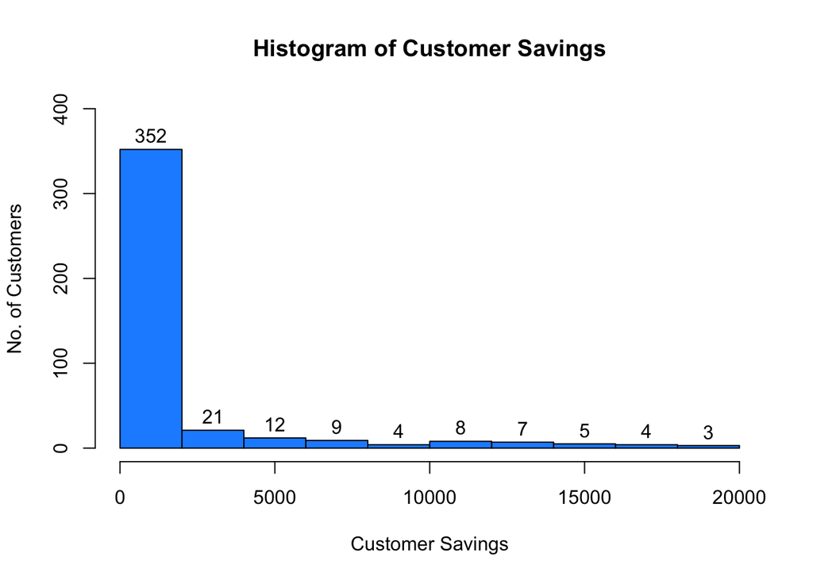

```r
# Savings
# create histogram
h2<-hist(BD$Savings, main="Histogram of Customer Savings",xlab="Customer Savings",ylab="No. of Customers", ylim=c(0,400), col=c("dodgerblue"), labels=TRUE)
```

```r
# extract frequency table from hist()
Savings.Group<-cut(BD$Savings,h2$breaks)
t2<-table(Savings.Group)
kable(t2, caption = "Frequency distribution by Savings Group")
```

Frequency distribution by Savings Group

| Savings.Group | Freq |
| --- | --- |
| (0,2e+03] | 290 |
| (2e+03,4e+03] | 21 |
| (4e+03,6e+03] | 12 |
| (6e+03,8e+03] | 9 |
| (8e+03,1e+04] | 4 |
| (1e+04,1.2e+04] | 8 |
| (1.2e+04,1.4e+04] | 7 |
| (1.4e+04,1.6e+04] | 5 |
| (1.6e+04,1.8e+04] | 4 |
| (1.8e+04,2e+04] | 3 |

#### ii) Linear relationship between age and savings

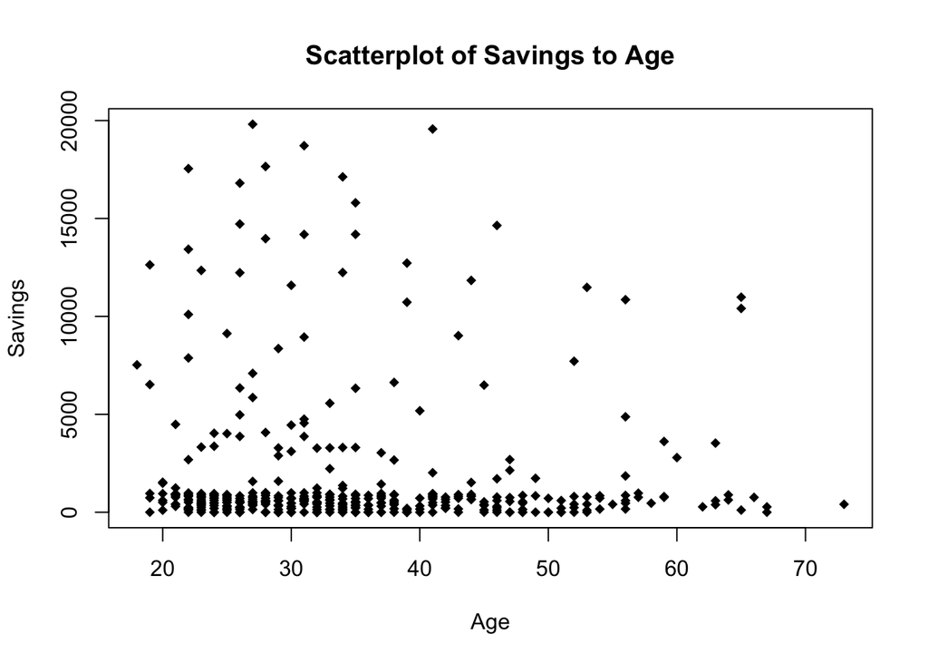

```r
# plot a scatterplot
plot(BD$Age,BD$Savings, main="Scatterplot of Savings to Age", xlab="Age", ylab="Savings", pch=18)
```

```r
#no clear pattern btw the two variables as alot of points are cluttered at the bottom.

# Now we compute statistical measures to assess the extent of linear correlation
# compute Covariance of Age and Savings
cov.AS<-cov(BD$Age, BD$Savings)
print("Covariance: ")
```

```
## [1] "Covariance: "
```

```r
cov.AS
```

```
## [1] -1123.868
```

```r
#Compute Pearson's Correlation Coefficient for Age and Savings
cor.AS <- cor(BD$Age, BD$Savings)
print ("Correlation Coefficient of Age and Savings: ")
```

```
## [1] "Correlation Coefficient of Age and Savings: "
```

```r
cor.AS
```

```
## [1] -0.02828589
```

**From the scatterplot, what can we say about the relationship between Age and Savings?**

### B) Loan Profile Dashboard

**Purpose: To understand the frequency of loans taken by the customers**

#### i) Frequency Distribution/ Charts for Loan Purpose

```r
LoanFreq<-BD%>%count(`Loan Purpose`)
kable(LoanFreq, caption = "Frequency Distribution for Loan Purpose")
```

Frequency Distribution for Loan Purpose

| Loan Purpose | n |
| --- | --- |
| Business | 44 |
| Education | 23 |
| Furniture | 85 |
| Large Appliance | 4 |
| New Car | 104 |
| Other | 6 |
| Repairs | 12 |
| Retraining | 2 |
| Small Appliance | 105 |
| Used Car | 40 |

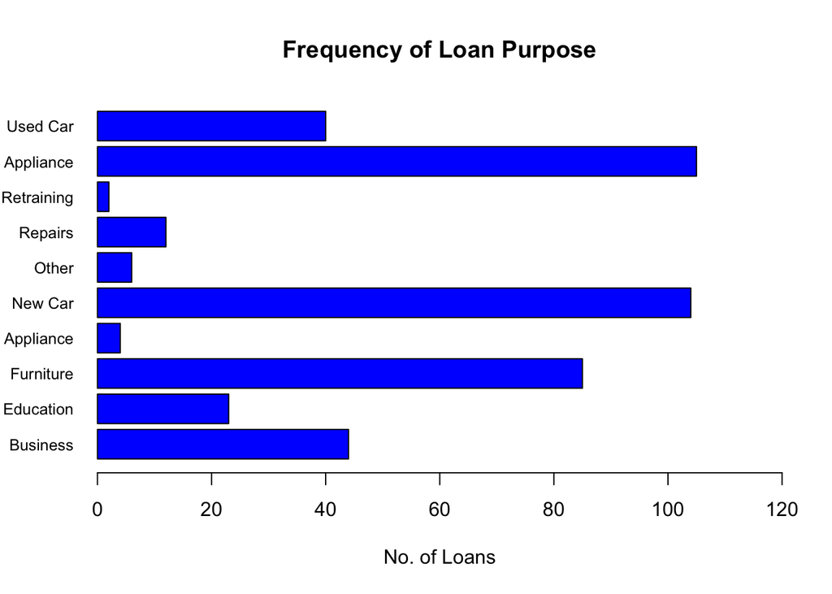

```r
Loanbar <- LoanFreq$n

# Horizontal
barplot(Loanbar,names.arg=LoanFreq$`Loan Purpose`,col="blue", beside = TRUE, main="Frequency of Loan Purpose", cex.names = 0.8, xlim=c(0,120), xlab="No. of Loans", horiz=TRUE, las=1)
```

### C) Loan Customer Analyses Dashboard

**Purpose: To compare loan types across different customer profiles (e.g. gender)**

#### i) Frequency Distribution/ Charts for Loan Purpose by Customer Gender (Categorical)

```r
# Create contingency table for loan purpose and gender with loan purpose as columns and gender as rows
BD3 <- BD %>% group_by(`Loan Purpose`,Gender) %>% tally()
BD3.spread<- BD3 %>% spread(key=`Loan Purpose`,value=n)
BD3.spread[is.na(BD3.spread)]<-0 #convert NA to 0 value
kable(BD3.spread, caption = "Contingency Table for Gender & Loan Purpose")
```

Contingency Table for Gender & Loan Purpose

| Gender | Business | Education | Furniture | Large Appliance | New Car | Other | Repairs | Retraining | Small Appliance | Used Car |
| --- | --- | --- | --- | --- | --- | --- | --- | --- | --- | --- |
| F | 9 | 12 | 37 | 1 | 34 | 1 | 4 | 0 | 32 | 5 |
| M | 35 | 11 | 48 | 3 | 70 | 5 | 8 | 2 | 73 | 35 |

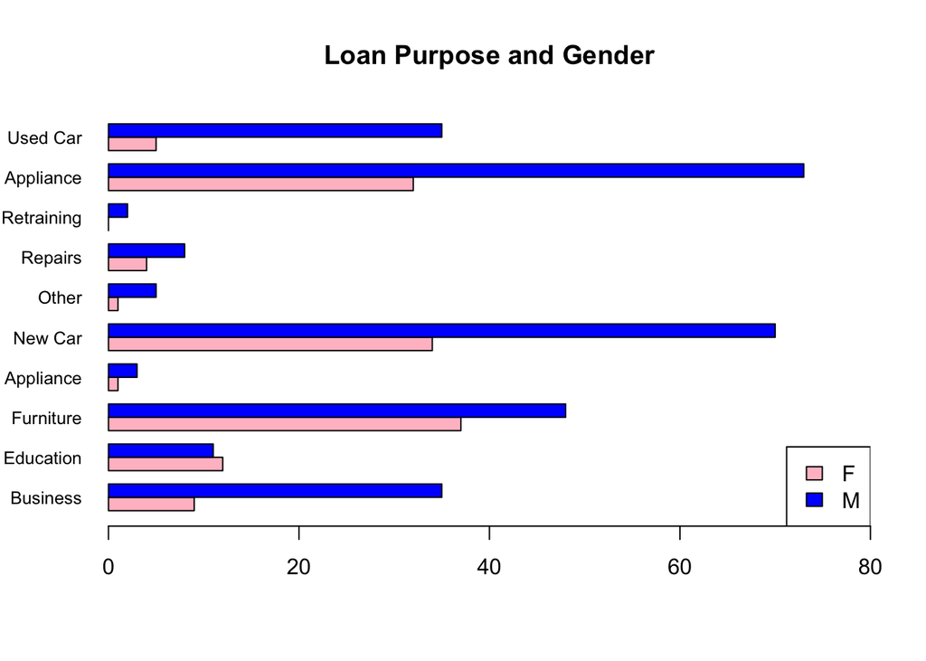

```r
#plot the grouped barplot
barmatrix.BD3<-as.matrix(BD3.spread[,c(2:11)])
# plot horizontal grouped barplot
barplot(barmatrix.BD3, beside = TRUE, horiz=TRUE, col =c("pink","blue"), main="Loan Purpose and Gender", xlim=c(0,80), cex.names=0.8, las=1)
legend("bottomright", cex=1, fill=c("pink","blue"), BD3.spread$Gender)
```

**Since both variables are categorical variables, we will use the grouped bar chart to compare frequencies across of loan types across each gender type (female and male). From the charts, we can see frequency of loans are generally higher for MALES compared to FEMALES, regardless of type of loans (except for Education).**

#### ii) Descriptive Statistics for Age by Loan Purpose

```r
# Create summary statistics of Age by loan purpose
mat.ALP<-describeBy(BD$Age, group=BD$`Loan Purpose`, mat=TRUE, IQR=TRUE)
mat.ALP<- mat.ALP[,-c(1,3,7,8,15)] # remove item, vars, trimmed, mad and se columns in the matrix
kable(mat.ALP, caption = "Descriptive Statistics for Age grouped by Loan Purpose", row.names = FALSE)
```

Descriptive Statistics for Age grouped by Loan Purpose

| group1 | n | mean | sd | mad | min | max | range | skew | kurtosis | IQR |
| --- | --- | --- | --- | --- | --- | --- | --- | --- | --- | --- |
| Business | 44 | 34.65909 | 11.999890 | 8.1543 | 20 | 73 | 53 | 1.4912205 | 1.6235040 | 11.25 |
| Education | 23 | 37.69565 | 11.055376 | 8.8956 | 23 | 63 | 40 | 0.6911942 | -0.6454803 | 13.00 |
| Furniture | 85 | 30.51765 | 9.506404 | 8.8956 | 18 | 59 | 41 | 0.9299842 | 0.0791556 | 12.00 |
| Large Appliance | 4 | 38.75000 | 13.961256 | 13.3434 | 21 | 53 | 32 | -0.2177628 | -2.0560025 | 16.25 |
| New Car | 104 | 35.41346 | 10.619281 | 10.3782 | 20 | 67 | 47 | 0.9044464 | 0.3646041 | 15.00 |
| Other | 6 | 40.83333 | 10.107753 | 2.9652 | 28 | 59 | 31 | 0.6211123 | -0.8263536 | 3.00 |
| Repairs | 12 | 40.25000 | 15.783334 | 18.5325 | 21 | 66 | 45 | 0.2736550 | -1.4302518 | 19.25 |
| Retraining | 2 | 28.50000 | 12.020815 | 12.6021 | 20 | 37 | 17 | 0.0000000 | -2.7500000 | 8.50 |
| Small Appliance | 105 | 34.13333 | 11.218174 | 10.3782 | 20 | 65 | 45 | 0.9714090 | 0.1989060 | 16.00 |
| Used Car | 40 | 35.65000 | 10.196908 | 10.3782 | 22 | 62 | 40 | 0.7110061 | -0.3328265 | 14.00 |

```r
#plot the grouped barplot of mean Age by loan purpose
mean.age <- BD%>%group_by(`Loan Purpose`) %>% summarise(mean=mean(Age))
kable(mean.age)
```

| Loan Purpose | mean |
| --- | --- |
| Business | 34.65909 |
| Education | 37.69565 |
| Furniture | 30.51765 |
| Large Appliance | 38.75000 |
| New Car | 35.41346 |
| Other | 40.83333 |
| Repairs | 40.25000 |
| Retraining | 28.50000 |
| Small Appliance | 34.13333 |
| Used Car | 35.65000 |

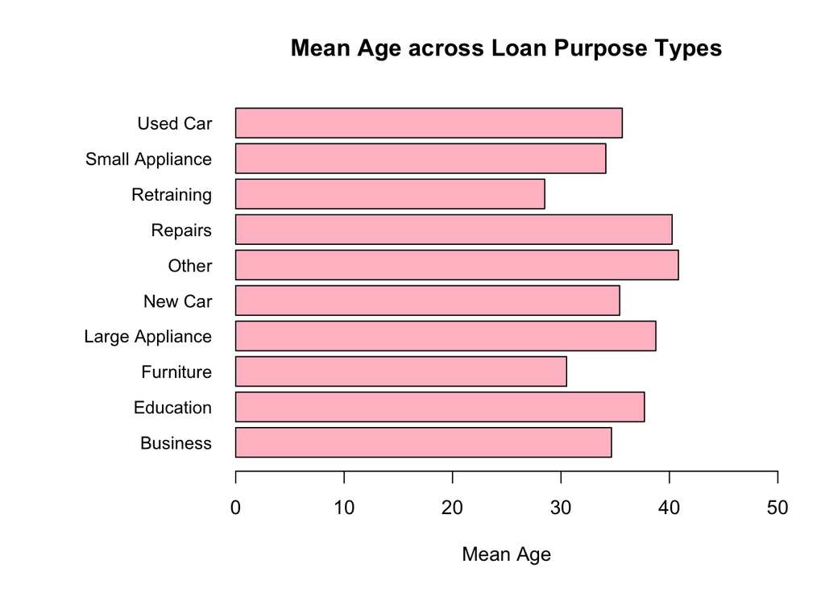

```r
mean.age.spread<- mean.age %>% spread(key=`Loan Purpose`,value=mean)
mat.meanage<-as.matrix(mean.age.spread[,c(1:10)])
#plot horizontal grouped barplot
par(mar=c(5,10,4,2)) # default plot margin is (5,4,4,2), I'm adding a bigger left margin for the barchart
barplot(mat.meanage, horiz=TRUE, col =c("pink"), main="Mean Age across Loan Purpose Types", cex.names=0.9, las=1, xlim=c(0,50), xlab="Mean Age")
```

#### iii) Descriptive Statistics for Savings by Loan Purpose

```r
# Create summary statistics of Savings by loan purpose
mat.SLP<-describeBy(BD$Savings, group=BD$`Loan Purpose`, mat=TRUE, IQR=TRUE)
mat.SLP<- mat.SLP[,-c(1,3,7,8,15)] # remove item, vars, trimmed, mad and se columns in the matrix
kable(mat.SLP, caption = "Descriptive Statistics for Savings grouped by Loan Purpose", row.names = FALSE)
```

Descriptive Statistics for Savings grouped by Loan Purpose

| group1 | n | mean | sd | mad | min | max | range | skew | kurtosis | IQR |
| --- | --- | --- | --- | --- | --- | --- | --- | --- | --- | --- |
| Business | 44 | 1421.8182 | 2114.5092 | 619.7268 | 0 | 11481 | 11481 | 2.7812825 | 9.3526206 | 856.50 |
| Education | 23 | 1337.3913 | 2701.4711 | 597.4878 | 0 | 12348 | 12348 | 3.0070681 | 9.1528107 | 748.00 |
| Furniture | 85 | 1916.2235 | 3665.2197 | 502.6014 | 0 | 17545 | 17545 | 2.5904106 | 5.9745258 | 649.00 |
| Large Appliance | 4 | 4555.5000 | 7504.0040 | 614.5377 | 409 | 15800 | 15391 | 0.7454158 | -1.6905793 | 4195.00 |
| New Car | 104 | 1518.7404 | 3183.7217 | 451.4517 | 0 | 19811 | 19811 | 3.5727463 | 13.3981036 | 655.00 |
| Other | 6 | 979.6667 | 1348.0810 | 657.5331 | 0 | 3613 | 3613 | 1.1076838 | -0.4781666 | 748.25 |
| Repairs | 12 | 753.5000 | 687.8333 | 213.4944 | 0 | 2688 | 2688 | 1.6047011 | 2.4762388 | 307.25 |
| Retraining | 2 | 301.5000 | 426.3854 | 447.0039 | 0 | 603 | 603 | 0.0000000 | -2.7500000 | 301.50 |
| Small Appliance | 105 | 2393.3238 | 4552.5102 | 524.8404 | 0 | 19568 | 19568 | 2.4515501 | 4.9794792 | 631.00 |
| Used Car | 40 | 1778.6750 | 3627.1619 | 530.7708 | 0 | 14717 | 14717 | 2.3841328 | 4.6653039 | 792.25 |

```r
#plot the grouped barplot of mean Age by loan purpose
mean.save <- BD%>%group_by(`Loan Purpose`) %>% summarise(mean=mean(Savings))
kable(mean.save)
```

| Loan Purpose | mean |
| --- | --- |
| Business | 1421.8182 |
| Education | 1337.3913 |
| Furniture | 1916.2235 |
| Large Appliance | 4555.5000 |
| New Car | 1518.7404 |
| Other | 979.6667 |
| Repairs | 753.5000 |
| Retraining | 301.5000 |
| Small Appliance | 2393.3238 |
| Used Car | 1778.6750 |

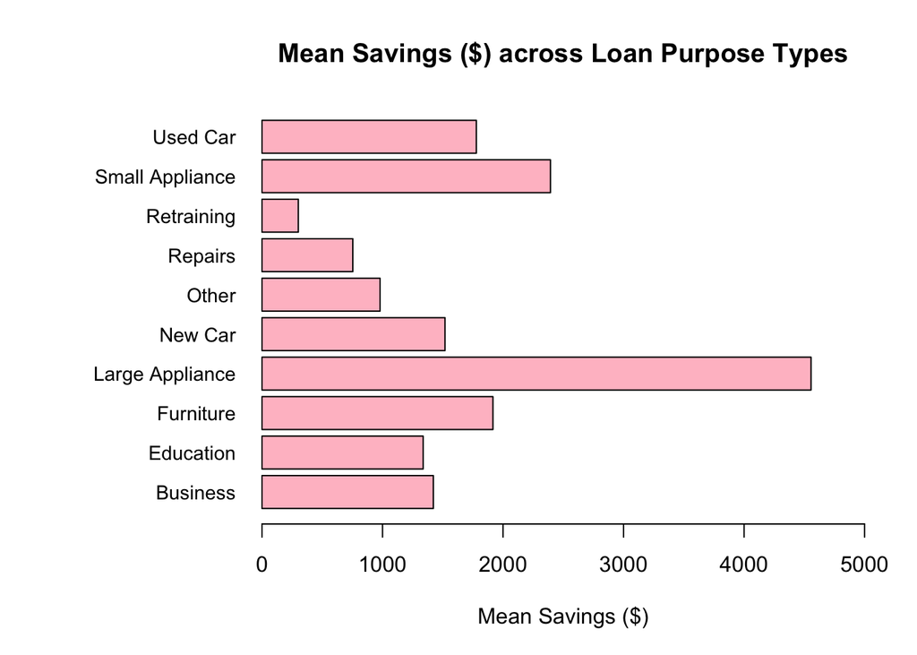

```r
mean.save.spread<- mean.save %>% spread(key=`Loan Purpose`,value=mean)
mat.meansave<-as.matrix(mean.save.spread[,c(1:10)])
#plot horizontal grouped barplot
par(mar=c(5,10,4,2)) # default plot margin is (5,4,4,2), I'm adding a bigger left margin for the barchart
barplot(mat.meansave, horiz=TRUE, col =c("pink"), main="Mean Savings ($) across Loan Purpose Types", cex.names=0.9, las=1, xlim=c(0,5000), xlab="Mean Savings ($)")
```

#### iv) Descriptive Statistics for Age by Loan Purpose & Gender

```r
# Create summary statistics of Age by loan purpose & gender
mat.ALP2<-describeBy(BD$Age, group=list(BD$`Loan Purpose`, BD$Gender), mat=TRUE, IQR=TRUE)
mat.ALP2<- mat.ALP2[,-c(1,4,9,10,16)] # remove item, vars, trimmed, mad and se columns in the matrix
kable(mat.ALP2, caption = "Descriptive Statistics for Age grouped by Loan Purpose & Gender", row.names = FALSE)
```

Descriptive Statistics for Age grouped by Loan Purpose & Gender

| group1 | group2 | n | mean | sd | median | min | max | range | skew | kurtosis | IQR |
| --- | --- | --- | --- | --- | --- | --- | --- | --- | --- | --- | --- |
| Business | F | 9 | 33.66667 | 11.180340 | 31.0 | 23 | 58 | 35 | 0.9470063 | -0.2863716 | 13.00 |
| Education | F | 12 | 36.75000 | 11.529606 | 33.0 | 23 | 56 | 33 | 0.6042837 | -1.2491877 | 13.25 |
| Furniture | F | 37 | 25.48649 | 6.690049 | 24.0 | 18 | 48 | 30 | 1.7700775 | 3.1045159 | 5.00 |
| Large Appliance | F | 1 | 21.00000 | NA | 21.0 | 21 | 21 | 0 | NA | NA | 0.00 |
| New Car | F | 34 | 29.85294 | 9.062518 | 28.0 | 20 | 53 | 33 | 1.3686339 | 0.9505358 | 9.50 |
| Other | F | 1 | 59.00000 | NA | 59.0 | 59 | 59 | 0 | NA | NA | 0.00 |
| Repairs | F | 4 | 41.00000 | 22.479620 | 38.0 | 22 | 66 | 44 | 0.0903193 | -2.3344462 | 35.00 |
| Retraining | F | NA | NA | NA | NA | NA | NA | NA | NA | NA | NA |
| Small Appliance | F | 32 | 36.46875 | 13.854042 | 32.0 | 21 | 65 | 44 | 0.6981130 | -0.8491797 | 19.25 |
| Used Car | F | 5 | 37.60000 | 15.789237 | 30.0 | 22 | 57 | 35 | 0.2469839 | -2.1638679 | 25.00 |
| Business | M | 35 | 34.91429 | 12.344018 | 32.0 | 20 | 73 | 53 | 1.5263862 | 1.6434518 | 10.50 |
| Education | M | 11 | 38.72727 | 10.973522 | 39.0 | 26 | 63 | 37 | 0.7420758 | -0.3689592 | 12.00 |
| Furniture | M | 48 | 34.39583 | 9.588867 | 32.0 | 19 | 59 | 40 | 0.5731193 | -0.4513391 | 14.25 |
| Large Appliance | M | 3 | 44.66667 | 9.073772 | 46.0 | 35 | 53 | 18 | -0.1437708 | -2.3333333 | 9.00 |
| New Car | M | 70 | 38.11429 | 10.316081 | 36.0 | 24 | 67 | 43 | 0.8872936 | 0.4273385 | 13.75 |
| Other | M | 5 | 37.20000 | 5.357238 | 39.0 | 28 | 42 | 14 | -0.8532141 | -1.1264369 | 1.00 |
| Repairs | M | 8 | 39.87500 | 13.206465 | 38.0 | 21 | 64 | 43 | 0.3673371 | -1.0240909 | 15.00 |
| Retraining | M | 2 | 28.50000 | 12.020815 | 28.5 | 20 | 37 | 17 | 0.0000000 | -2.7500000 | 8.50 |
| Small Appliance | M | 73 | 33.10959 | 9.780311 | 31.0 | 20 | 65 | 45 | 0.9331989 | 0.3702947 | 11.00 |
| Used Car | M | 35 | 35.37143 | 9.449823 | 34.0 | 22 | 62 | 40 | 0.7435225 | 0.0666247 | 12.00 |

```r
#plot the grouped barplot of mean Age by loan purpose
mean.age2 <- BD%>%group_by(`Loan Purpose`,Gender) %>% summarise(mean=mean(Age))
kable(mean.age2)
```

| Loan Purpose | Gender | mean |
| --- | --- | --- |
| Business | F | 33.66667 |
| Business | M | 34.91429 |
| Education | F | 36.75000 |
| Education | M | 38.72727 |
| Furniture | F | 25.48649 |
| Furniture | M | 34.39583 |
| Large Appliance | F | 21.00000 |
| Large Appliance | M | 44.66667 |
| New Car | F | 29.85294 |
| New Car | M | 38.11429 |
| Other | F | 59.00000 |
| Other | M | 37.20000 |
| Repairs | F | 41.00000 |
| Repairs | M | 39.87500 |
| Retraining | M | 28.50000 |
| Small Appliance | F | 36.46875 |
| Small Appliance | M | 33.10959 |
| Used Car | F | 37.60000 |
| Used Car | M | 35.37143 |

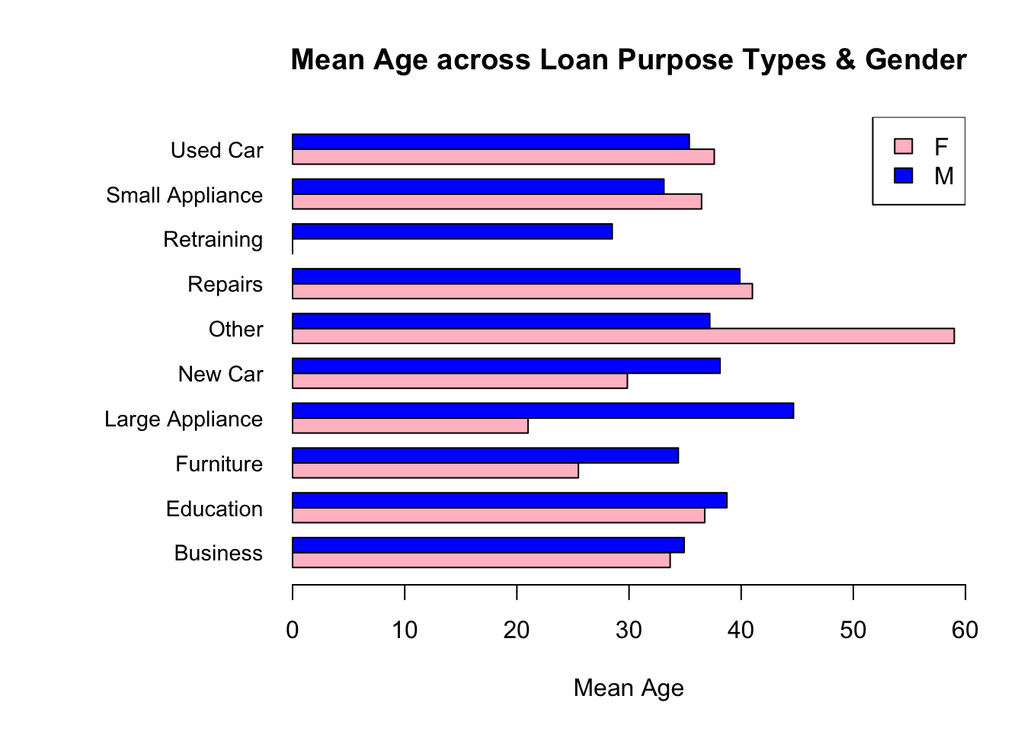

```r
mean.age2.spread<- mean.age2 %>% spread(key=`Loan Purpose`,value=mean)
mean.age2.spread[is.na(mean.age2.spread)] <- 0 #putting 0 to the NA values so that the bar for retraining for M will display
mat.meanage2<-as.matrix(mean.age2.spread[,c(2:11)])
#plot horizontal grouped barplot
par(mar=c(5,10,4,2)) # default plot margin is (5,4,4,2), I'm adding a bigger left margin for the barchart
barplot(mat.meanage2, horiz=TRUE, beside= TRUE, col =c("pink","blue"), main="Mean Age across Loan Purpose Types & Gender", cex.names=0.9, xlim=c(0,60), las=1,  xlab="Mean Age")
legend("topright", cex=1, fill=c("pink","blue"), mean.age2.spread$Gender)
```

### D) Customer Savings Outlier Analyses Dashboard

**Purpose: To conduct outlier analyses on savings**

#### i) Check distribution of Savings

```r
# Conduct Shapiro-Wilkins Test
shapiro.test(BD$Savings)
```

```
##
##  Shapiro-Wilk normality test
##
## data:  BD$Savings
## W = 0.51006, p-value < 2.2e-16
```

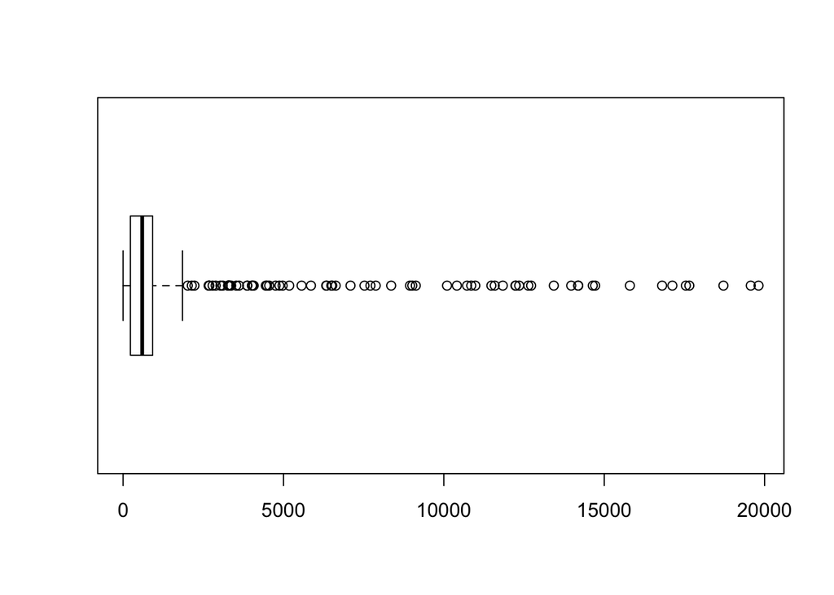

```r
# Since data is not normally distributed, we can use Chebyshev's Theorem to identify data that is within 3 sd of the mean. Then use Z-scores > +3 or < -3 for outlier identification

boxplot(BD$Savings, horizontal=TRUE) #applying 1.5*IQR to the left of Q1 or right of Q3
```

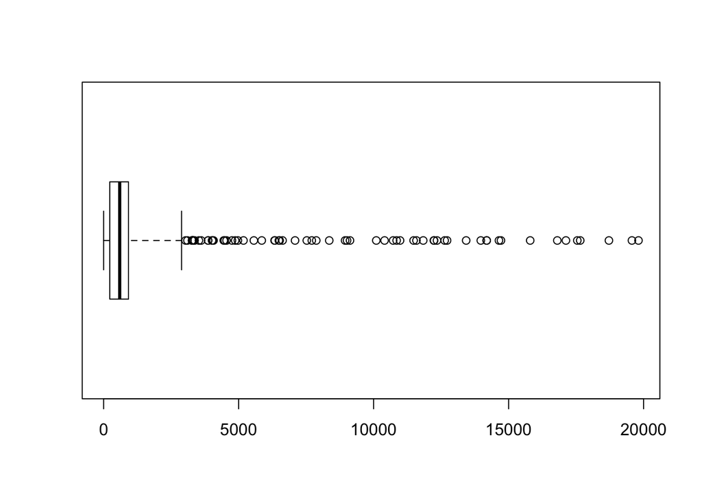

```r
boxplot(BD$Savings, horizontal=TRUE, range=3 ) #applying 3*IQR to the left of Q1 or right of Q3
```

# Building Dashboards for Food Order Demand

**This dataset comprises of 105 daily food order demand data for a restaurant.** Each of the column is defined as follows:

- `Day` : A running number indicating the day from when data was captured, ie “1” indicate Day 1, “2” indicates Day 2.
- `Demand` : Number of food orders for the day

**Let’s build a simple dashboard for the restaurant with this data**

## 1) Import and check the data

```r
#import excel file into RStudio
demand <- read.csv("~/Dropbox/Teaching/BT1101/BT1101AY2021S1/Inclass Lecture/Lecture 4/demand.csv")
D<-demand
head(D)
```

```
##   Day Demand
## 1   1    637
## 2   2    718
## 3   3    616
## 4   4    859
## 5   5    732
## 6   6    617
```

```r
str(D)
```

```
## 'data.frame':    105 obs. of  2 variables:
##  $ Day   : int  1 2 3 4 5 6 7 8 9 10 ...
##  $ Demand: int  637 718 616 859 732 617 748 773 757 669 ...
```

```r
summary(D)
```

```
##       Day          Demand
##  Min.   :  1   Min.   : 478.0
##  1st Qu.: 27   1st Qu.: 652.0
##  Median : 53   Median : 718.0
##  Mean   : 53   Mean   : 760.9
##  3rd Qu.: 79   3rd Qu.: 776.0
##  Max.   :105   Max.   :2100.0
```

## 2) Plot the data using histogram, boxplot and line chart

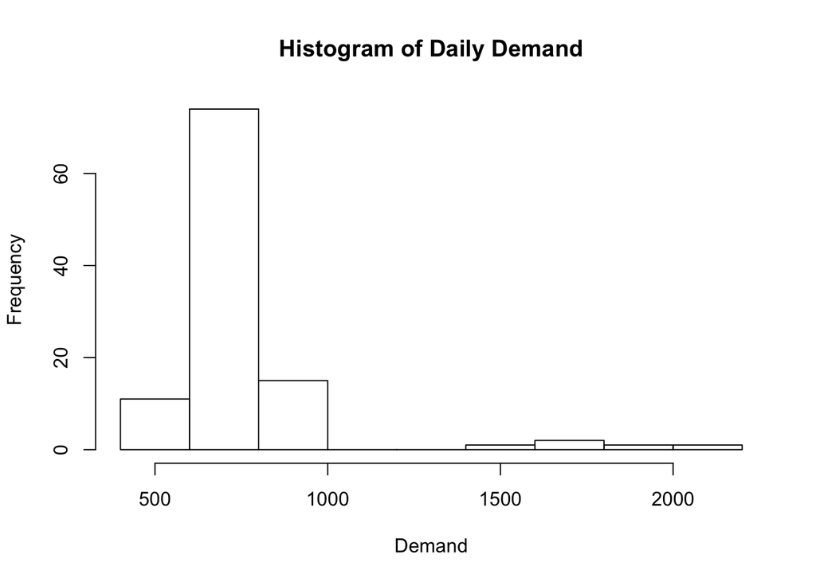

```r
# Plot the Histogram
hist(D$Demand, main="Histogram of Daily Demand", xlab = "Demand")
```

```r
# Use Shapiro-Wilkins Test to test if data is normally distributed
shapiro.test(D$Demand)
```

```
##
##  Shapiro-Wilk normality test
##
## data:  D$Demand
## W = 0.56684, p-value = 4.248e-16
```

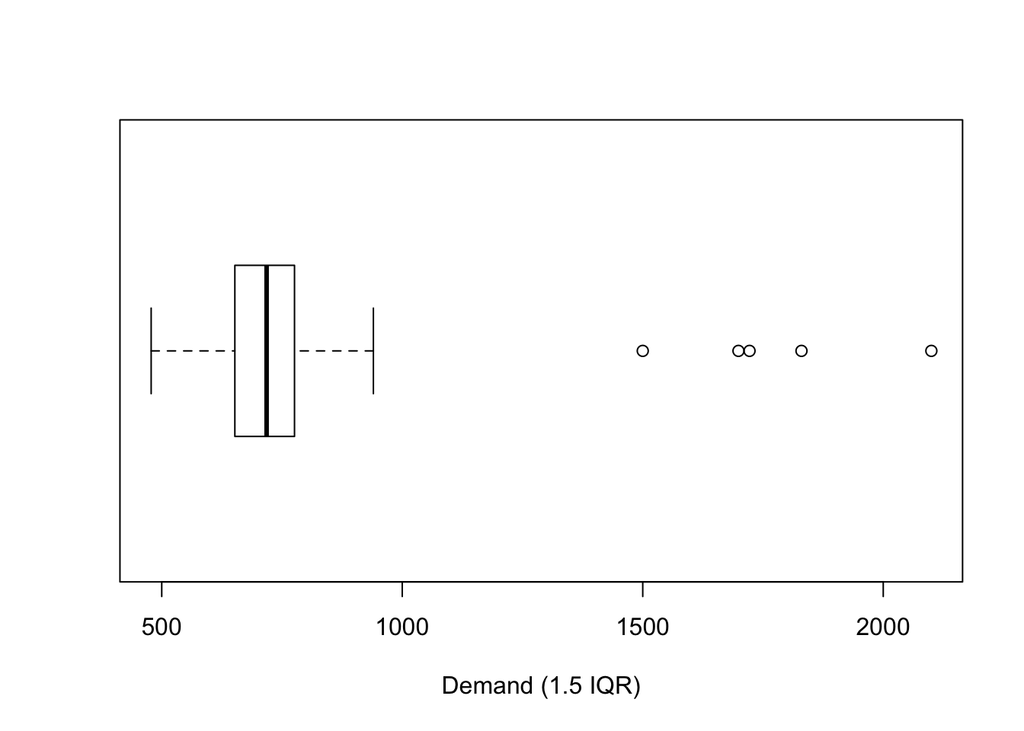

```r
# Plot boxplot to view the distribution of the data, and if outlier exists
boxplot(D$Demand, horizontal=TRUE, xlab="Demand (1.5 IQR)", range=1.5) #applying 1.5*IQR to the left of Q1 or right of Q3
```

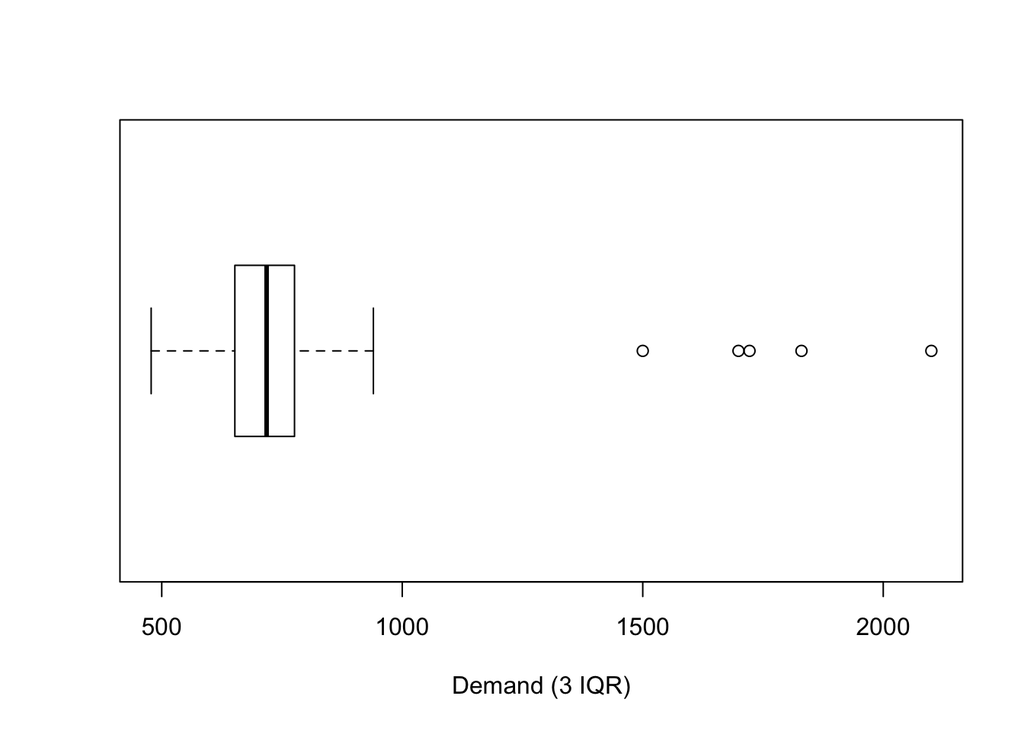

```r
boxplot(D$Demand, horizontal=TRUE, xlab="Demand (3 IQR)", range = 3) #applying 3*IQR to the left of Q1 or right of Q3
```

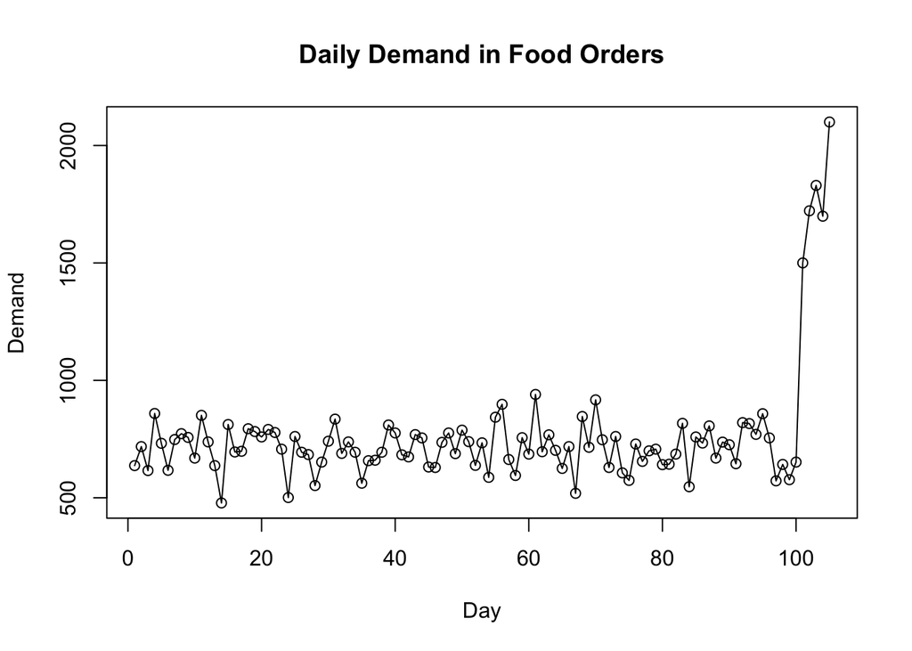

```r
# Plot line chart of Daily demand over time
plot(D$Day, D$Demand, main="Daily Demand in Food Orders", ylab="Demand", xlab="Day")
lines(D$Day, D$Demand)
```

## 3) Identify and remove outliers

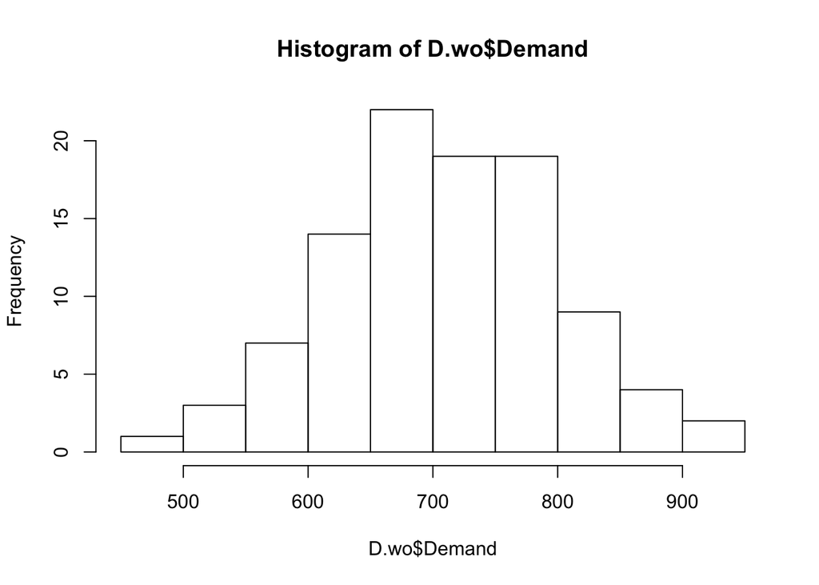

```r
# Let pull out the outliers from the data.
# From the chart, it looks quite clear that values => 1500 could count as outliers.

D.outlier<- D %>% filter(Demand>=1500) # this df contains just the outliers
D.wo<- D %>% filter(Demand<1500) # this df is without the outliers


# now let's run the same plots and analyses without the outliers.
hist(D.wo$Demand)
```

```r
shapiro.test(D.wo$Demand)
```

```
##
##  Shapiro-Wilk normality test
##
## data:  D.wo$Demand
## W = 0.9956, p-value = 0.9877
```

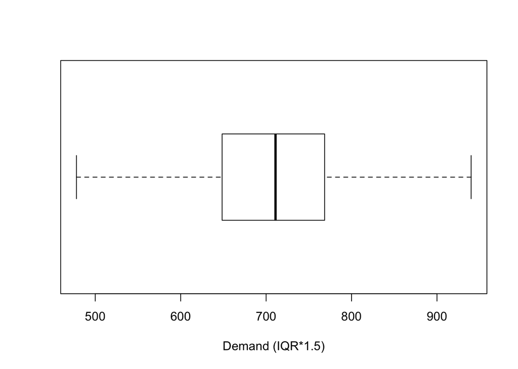

```r
# plot boxplot
boxplot(D.wo$Demand, xlab="Demand (IQR*1.5)",horizontal=TRUE, range=1.5) #applying 1.5*IQR to the left of Q1 or right of Q3
```

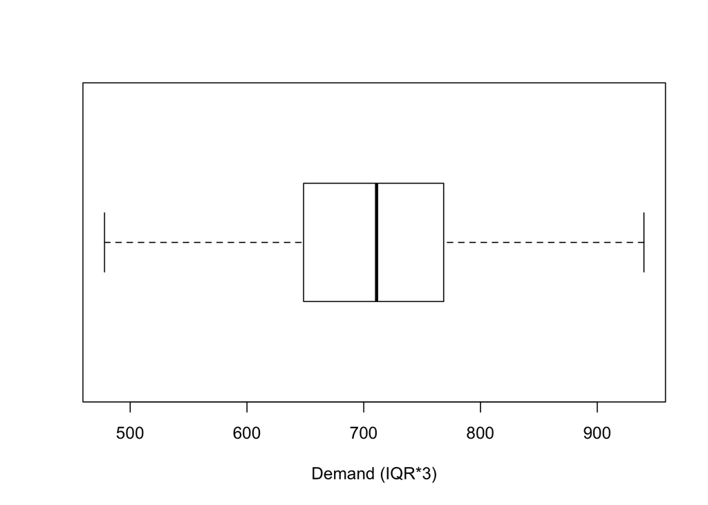

```r
boxplot(D.wo$Demand, xlab="Demand (IQR*3)", horizontal=TRUE,range = 3) #applying 3*IQR to the left of Q1 or right of Q3
```

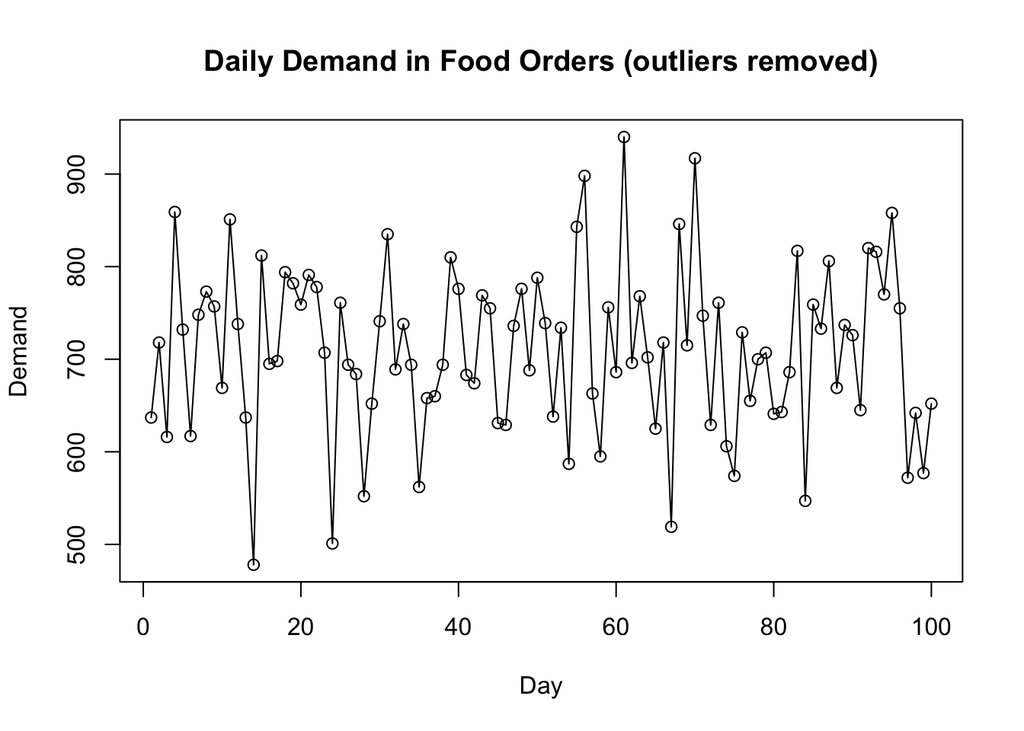

```r
# plot line chart
plot(D.wo$Day, D.wo$Demand, main="Daily Demand in Food Orders (outliers removed)", ylab="Demand", xlab="Day")
lines(D.wo$Day, D.wo$Demand)
```

## 4) Impute outliers with mean

```r
# Another way to handle outliers is to impute with mean data.
D$Demand.imp <- D$Demand
D$Demand.imp[D$Demand>=1500]<-mean(D$Demand)
```

## 5) Dashboard with imputed data

### i) now let’s run the same plots and analyses with imputed mean data for outliers.

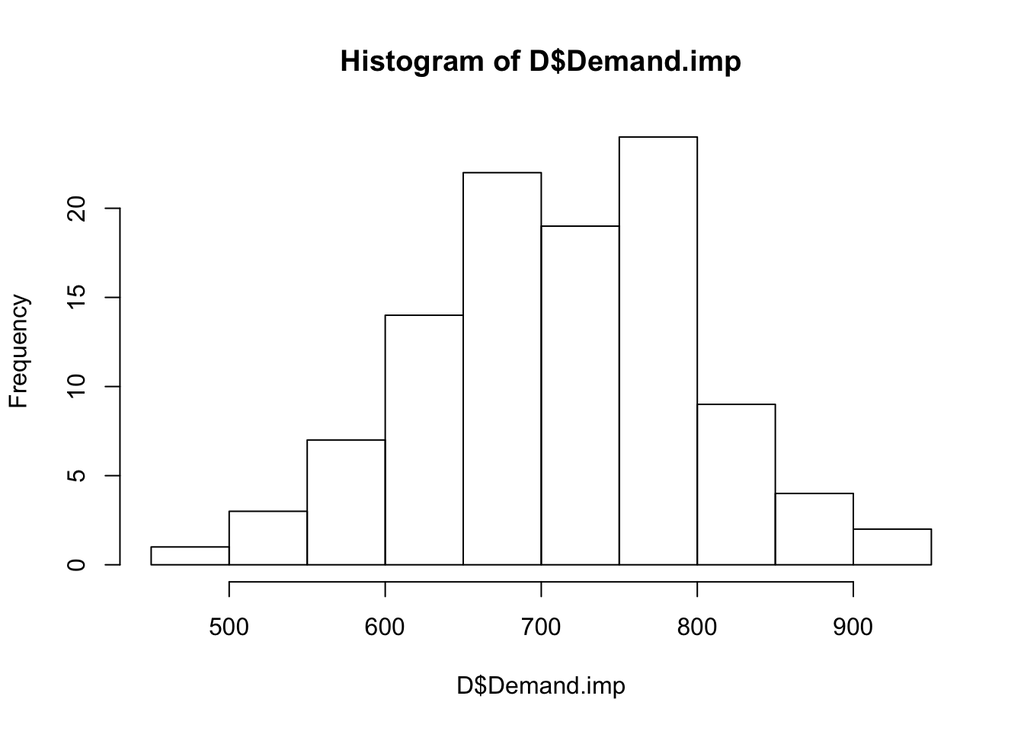

```r
# Plot histogram
hist(D$Demand.imp)
```

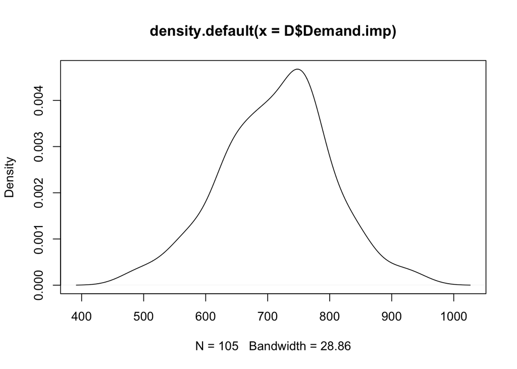

```r
# Other graphical methods to check for normality: 1) Density plot 2) Q-Q plot
# Density Plot (smoothed version of the histogram)
plot(density(D$Demand.imp))
```

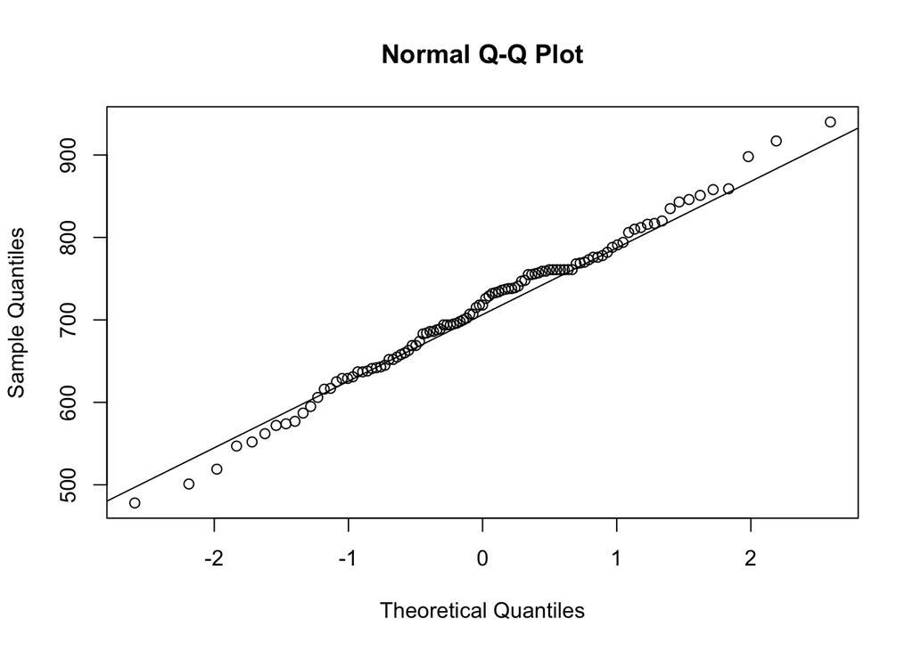

```r
# Q-Q plot (draws the correlation between a given sample and the normal distribution. A 45-degree reference line is also plotted)
qqnorm(D$Demand.imp)
qqline(D$Demand.imp)
```

```r
# run shapiro Wilkins to test for normality
shapiro.test(D$Demand.imp)
```

```
##
##  Shapiro-Wilk normality test
##
## data:  D$Demand.imp
## W = 0.99233, p-value = 0.8225
```

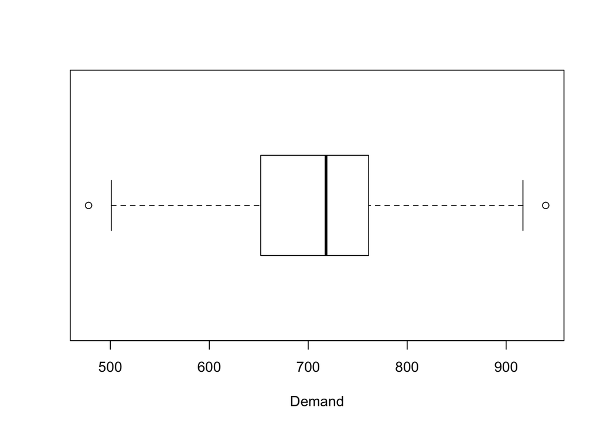

```r
# Draw boxplots
boxplot(D$Demand.imp, horizontal=TRUE, xlab="Demand") #applying 1.5*IQR to the left of Q1 or right of Q3
```

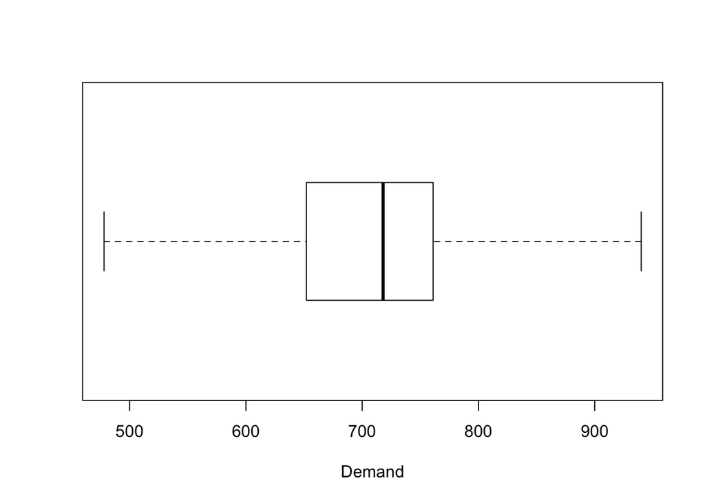

```r
boxplot(D$Demand.imp, horizontal=TRUE, xlab="Demand", range = 3) #applying 3*IQR to the left of Q1 or right of Q3
```

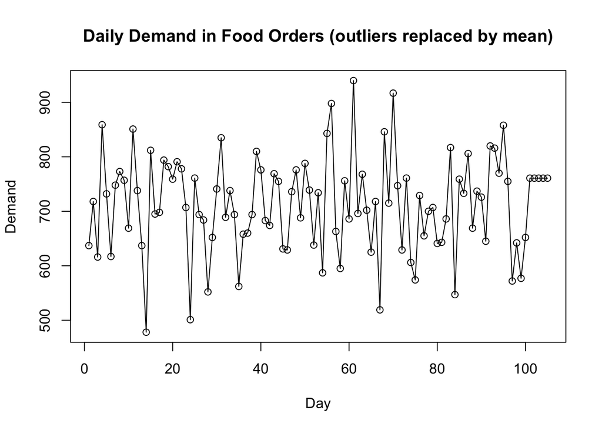

```r
# Plot line chart
plot(D$Day, D$Demand.imp, main="Daily Demand in Food Orders (outliers replaced by mean)", ylab="Demand", xlab="Day")
lines(D$Day, D$Demand.imp)
```

### ii) Show the descriptive Statistics for Demand

```r
# Use describe() function in psych package to generate the descriptive statistics
df.d <- describe(D$Demand.imp, IQR=TRUE)
df.d$trimmed <- df.d$mad <- df.d$se <- NULL # remove se, mad and trimmed if not needed
df.d$vars[1]<-"Demand"
kable(df.d, row.names = FALSE, caption = "Descriptive Statistics for Demand")
```

Descriptive Statistics for Demand

| vars | n | mean | sd | median | min | max | range | skew | kurtosis | IQR |
| --- | --- | --- | --- | --- | --- | --- | --- | --- | --- | --- |
| Demand | 105 | 712.8032 | 88.30803 | 718 | 478 | 940 | 462 | -0.1412015 | 0.0250254 | 109 |

### iii) Computing Probabilities using the imputed data

**Let’s try to compute the following probabilities: 1) Demand > 800, 2) Demand < 550, 3) 700 < Demand < 800** **Using empirical data to compute probabilities**

```r
# 1) Demand.imp > 800
d1<- D %>% filter(Demand.imp>800)
pr1 <- nrow(d1)/nrow(D)
print ("Probabilty of Demand > 800: ")
```

```
## [1] "Probabilty of Demand > 800: "
```

```r
pr1
```

```
## [1] 0.1428571
```

```r
# 2) Demand.imp < 550
d2<-D %>% filter(Demand.imp<550 )
pr2 <- nrow(d2)/nrow(D)
print ("Probabilty of Demand < 550: ")
```

```
## [1] "Probabilty of Demand < 550: "
```

```r
pr2
```

```
## [1] 0.03809524
```

```r
# 3) 700 < Demand.imp < 800
d3<-D %>% filter(Demand.imp<800 & Demand.imp>700)
pr3 <- nrow(d3)/nrow(D)
print ("Probabilty of 700< Demand < 800: ")
```

```
## [1] "Probabilty of 700< Demand < 800: "
```

```r
pr3
```

```
## [1] 0.4095238
```

**What if we don’t have the raw demand data. Instead we have summary data of the mean and std deviation for demand. We are also told that demand is normally distributed. How can we compute the above probabilities using the standard normal distribution**

```r
m<-mean(D$Demand.imp)
s<-sd(D$Demand.imp)

# 1) Demand.imp > 800
pr11<-pnorm(800,mean=m, sd=s, lower.tail = FALSE)
print ("Probabilty of Demand > 800: ")
```

```
## [1] "Probabilty of Demand > 800: "
```

```r
pr11
```

```
## [1] 0.1617192
```

```r
# 2) Demand.imp < 550
pr22 <- pnorm(550,mean=m, sd=s, lower.tail = TRUE)
print ("Probabilty of Demand < 550: ")
```

```
## [1] "Probabilty of Demand < 550: "
```

```r
pr22
```

```
## [1] 0.03262197
```

```r
# 3) 700 < Demand.imp < 800
pr33 <- pnorm(800,mean=m, sd=s, lower.tail = TRUE) - pnorm(700,mean=m, sd=s, lower.tail = TRUE)
print ("Probabilty of 700< Demand < 800: ")
```

```
## [1] "Probabilty of 700< Demand < 800: "
```

```r
pr33
```

```
## [1] 0.3959187
```